# K-means Clustering

## A cluster refers to a collection of data points aggregated together because of certain similarities. K-means clustering is one of the simplest and popular unsupervised machine learning algorithms.

K-means clustering is an iterative algorithm that partitions a group of data containing n values into k subgroups. Each of the n value belongs to the k cluster with the nearest mean.

This means that given a group of objects, we partition that group into several sub-groups. These sub-groups are formed on the basis of their similarity and the distance of each data-point in the sub-group with the mean of their centroid. K-means clustering is the most popular form of an unsupervised learning algorithm. It is easy to understand and implement.

the algorithm for K-means clustering –

1.First, we randomly initialize and select the k-points. These k-points are the means.

2.We use the Euclidean distance to find data-points that are closest to their centreW of the cluster.

3.Then we calculate the mean of all the points in the cluster which is finding their centroid.

4.We iteratively repeat step 1, 2 and 3 until all the points are assigned to their respective clusters.

K-Means is a non-hierarchical clustering method.

# Finding K values

These methods are:

1.The Elbow Method

2.The Silhouette Method

## Elbow Method

Each cluster is formed by calculating and comparing the distances of data points within a cluster to its centroid. An ideal way to figure out the right number of clusters would be to calculate the Within-Cluster-Sum-of-Squares (WCSS).

WCSS is the sum of squares of the distances of each data point in all clusters to their respective centroids.

[figure not shown]

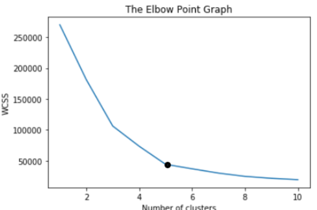

## Silhouette Score

This is a better measure to decide the number of clusters to be formulated from the data. It is calculated for each instance and the formula goes like this:

**Silhouette Coefficient = (x-y)/ max(x,y)**.

where, y is the mean intra cluster distance: mean distance to the other instances in the same cluster.

x depicts mean nearest cluster distance i.e. mean distance to the instances of the next closest cluster.

The coefficient varies between -1 and 1. A value close to 1 implies that the instance is close to its cluster is a part of the right cluster. Whereas, a value close to -1 means that the value is assigned to the wrong cluster.

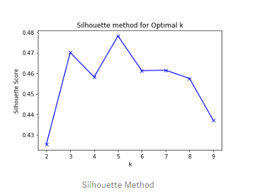

```python
import pandas as pd
```

```python
data = pd.read_csv("C:\\Users\\MEDHINI\\Desktop\\customer-segmentation-dataset\\customer-segmentation-dataset\\Mall_Customers.csv")
```

```python
data.shape
```

```
(200, 5)
```

```python
data.head()
```

|  | CustomerID | Gender | Age | Annual Income (k$) | Spending Score (1-100) |
| --- | --- | --- | --- | --- | --- |
| 0 | 1 | Male | 19 | 15 | 39 |
| 1 | 2 | Male | 21 | 15 | 81 |
| 2 | 3 | Female | 20 | 16 | 6 |
| 3 | 4 | Female | 23 | 16 | 77 |
| 4 | 5 | Female | 31 | 17 | 40 |

```python
data.describe()
```

|  | CustomerID | Age | Annual Income (k$) | Spending Score (1-100) |
| --- | --- | --- | --- | --- |
| count | 200.000000 | 200.000000 | 200.000000 | 200.000000 |
| mean | 100.500000 | 38.850000 | 60.560000 | 50.200000 |
| std | 57.879185 | 13.969007 | 26.264721 | 25.823522 |
| min | 1.000000 | 18.000000 | 15.000000 | 1.000000 |
| 25% | 50.750000 | 28.750000 | 41.500000 | 34.750000 |
| 50% | 100.500000 | 36.000000 | 61.500000 | 50.000000 |
| 75% | 150.250000 | 49.000000 | 78.000000 | 73.000000 |
| max | 200.000000 | 70.000000 | 137.000000 | 99.000000 |

```python
import matplotlib.pyplot as plt
import seaborn as sns
```

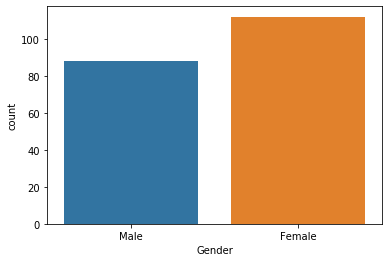

```python
sns.countplot(x="Gender",data=data)
```

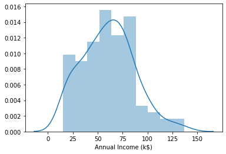

```python
sns.distplot(data['Annual Income (k$)'])
```

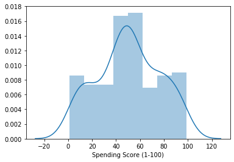

```python
sns.distplot(data['Spending Score (1-100)'])
```

```python
data1=data[data["Gender"]=="Female"]
```

```python
data1
```

|  | CustomerID | Gender | Age | Annual Income (k$) | Spending Score (1-100) |
| --- | --- | --- | --- | --- | --- |
| 2 | 3 | Female | 20 | 16 | 6 |
| 3 | 4 | Female | 23 | 16 | 77 |
| 4 | 5 | Female | 31 | 17 | 40 |
| 5 | 6 | Female | 22 | 17 | 76 |
| 6 | 7 | Female | 35 | 18 | 6 |
| 7 | 8 | Female | 23 | 18 | 94 |
| 9 | 10 | Female | 30 | 19 | 72 |
| 11 | 12 | Female | 35 | 19 | 99 |
| 12 | 13 | Female | 58 | 20 | 15 |
| 13 | 14 | Female | 24 | 20 | 77 |
| 16 | 17 | Female | 35 | 21 | 35 |
| 19 | 20 | Female | 35 | 23 | 98 |
| 22 | 23 | Female | 46 | 25 | 5 |
| 24 | 25 | Female | 54 | 28 | 14 |
| 26 | 27 | Female | 45 | 28 | 32 |
| 28 | 29 | Female | 40 | 29 | 31 |
| 29 | 30 | Female | 23 | 29 | 87 |
| 31 | 32 | Female | 21 | 30 | 73 |
| 34 | 35 | Female | 49 | 33 | 14 |
| 35 | 36 | Female | 21 | 33 | 81 |
| 36 | 37 | Female | 42 | 34 | 17 |
| 37 | 38 | Female | 30 | 34 | 73 |
| 38 | 39 | Female | 36 | 37 | 26 |
| 39 | 40 | Female | 20 | 37 | 75 |
| 40 | 41 | Female | 65 | 38 | 35 |
| 43 | 44 | Female | 31 | 39 | 61 |
| 44 | 45 | Female | 49 | 39 | 28 |
| 45 | 46 | Female | 24 | 39 | 65 |
| 46 | 47 | Female | 50 | 40 | 55 |
| 47 | 48 | Female | 27 | 40 | 47 |
| ... | ... | ... | ... | ... | ... |
| 143 | 144 | Female | 32 | 76 | 87 |
| 147 | 148 | Female | 32 | 77 | 74 |
| 148 | 149 | Female | 34 | 78 | 22 |
| 152 | 153 | Female | 44 | 78 | 20 |
| 153 | 154 | Female | 38 | 78 | 76 |
| 154 | 155 | Female | 47 | 78 | 16 |
| 155 | 156 | Female | 27 | 78 | 89 |
| 157 | 158 | Female | 30 | 78 | 78 |
| 159 | 160 | Female | 30 | 78 | 73 |
| 160 | 161 | Female | 56 | 79 | 35 |
| 161 | 162 | Female | 29 | 79 | 83 |
| 163 | 164 | Female | 31 | 81 | 93 |
| 165 | 166 | Female | 36 | 85 | 75 |
| 167 | 168 | Female | 33 | 86 | 95 |
| 168 | 169 | Female | 36 | 87 | 27 |
| 174 | 175 | Female | 52 | 88 | 13 |
| 175 | 176 | Female | 30 | 88 | 86 |
| 180 | 181 | Female | 37 | 97 | 32 |
| 181 | 182 | Female | 32 | 97 | 86 |
| 183 | 184 | Female | 29 | 98 | 88 |
| 184 | 185 | Female | 41 | 99 | 39 |
| 186 | 187 | Female | 54 | 101 | 24 |
| 188 | 189 | Female | 41 | 103 | 17 |
| 189 | 190 | Female | 36 | 103 | 85 |
| 190 | 191 | Female | 34 | 103 | 23 |
| 191 | 192 | Female | 32 | 103 | 69 |
| 193 | 194 | Female | 38 | 113 | 91 |
| 194 | 195 | Female | 47 | 120 | 16 |
| 195 | 196 | Female | 35 | 120 | 79 |
| 196 | 197 | Female | 45 | 126 | 28 |

112 rows × 5 columns

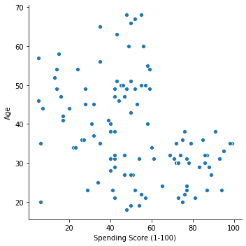

```python
sns.relplot(x="Spending Score (1-100)", y="Age", data=data1);
```

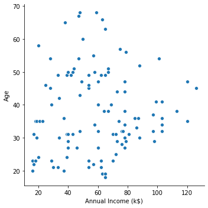

```python
sns.relplot(x="Annual Income (k$)", y="Age", data=data1);
```

```python
data2=data[data["Gender"]=="Male"]
```

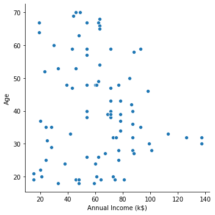

```python
sns.relplot(x="Annual Income (k$)", y="Age", data=data2);
```

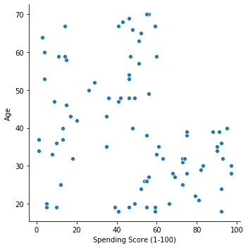

```python
sns.relplot(x="Spending Score (1-100)", y="Age", data=data2);
```

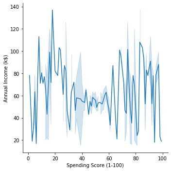

```python
sns.relplot(x="Spending Score (1-100)", y="Annual Income (k$)",kind="line" ,data=data);
```

```python
X = data.iloc[:,3:].values
```

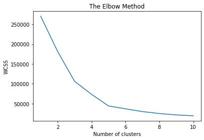

```python
from sklearn.cluster import KMeans
wcss = []
for i in range(1, 11):
    kmeans = KMeans(n_clusters = i, init = 'k-means++', random_state = 42)
    kmeans.fit(X)
    wcss.append(kmeans.inertia_)
plt.plot(range(1, 11), wcss)
plt.title('The Elbow Method')
plt.xlabel('Number of clusters')
plt.ylabel('WCSS')
plt.show()
```

```python
 kmeans = KMeans(n_clusters=5)
```

```python
y_kmeans = kmeans.fit_predict(X)
```

```python
kmeans.predict([[15, 60], [60, 30]])
```

```
array([4, 0])
```

```python
kmeans.labels_
```

```
array([3, 4, 3, 4, 3, 4, 3, 4, 3, 4, 3, 4, 3, 4, 3, 4, 3, 4, 3, 4, 3, 4,
       3, 4, 3, 4, 3, 4, 3, 4, 3, 4, 3, 4, 3, 4, 3, 4, 3, 4, 3, 4, 3, 0,
       3, 4, 0, 0, 0, 0, 0, 0, 0, 0, 0, 0, 0, 0, 0, 0, 0, 0, 0, 0, 0, 0,
       0, 0, 0, 0, 0, 0, 0, 0, 0, 0, 0, 0, 0, 0, 0, 0, 0, 0, 0, 0, 0, 0,
       0, 0, 0, 0, 0, 0, 0, 0, 0, 0, 0, 0, 0, 0, 0, 0, 0, 0, 0, 0, 0, 0,
       0, 0, 0, 0, 0, 0, 0, 0, 0, 0, 0, 0, 0, 1, 2, 1, 0, 1, 2, 1, 2, 1,
       0, 1, 2, 1, 2, 1, 2, 1, 2, 1, 0, 1, 2, 1, 2, 1, 2, 1, 2, 1, 2, 1,
       2, 1, 2, 1, 2, 1, 2, 1, 2, 1, 2, 1, 2, 1, 2, 1, 2, 1, 2, 1, 2, 1,
       2, 1, 2, 1, 2, 1, 2, 1, 2, 1, 2, 1, 2, 1, 2, 1, 2, 1, 2, 1, 2, 1,
       2, 1])
```

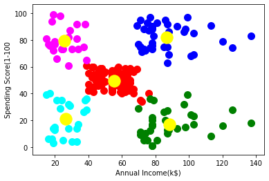

```python
plt.scatter(X[y_kmeans==0, 0], X[y_kmeans==0, 1], s=100, c='red', label ='Cluster 1')
plt.scatter(X[y_kmeans==1, 0], X[y_kmeans==1, 1], s=100, c='blue', label ='Cluster 2')
plt.scatter(X[y_kmeans==2, 0], X[y_kmeans==2, 1], s=100, c='green', label ='Cluster 3')
plt.scatter(X[y_kmeans==3, 0], X[y_kmeans==3, 1], s=100, c='cyan', label ='Cluster 4')
plt.scatter(X[y_kmeans==4, 0], X[y_kmeans==4, 1], s=100, c='magenta', label ='Cluster 5')
plt.scatter(kmeans.cluster_centers_[:, 0], kmeans.cluster_centers_[:, 1], s=300, c='yellow', label = 'Centroids')
plt.xlabel('Annual Income(k$)')
plt.ylabel('Spending Score(1-100')
```

cluster pattern:

1.Low income, low spending score

2.Low income, high spending score

3.Mid income, medium spending score

4.High income, low spending score

5.High income, high spending score